# R Notebook

Preparation

Reading in Files

```r
str(software)
```

```
'data.frame':   1000 obs. of  9 variables:
 $ freq        : int  2 2 4 1 5 1 2 2 2 2 ...
 $ last_update : int  3662 3883 525 3215 2081 1465 1879 2943 1928 1463 ...
 $ first_update: int  3662 3914 2914 3215 2438 1465 1914 2984 1983 1486 ...
 $ web_order   : int  1 0 1 0 0 0 1 1 0 0 ...
 $ gender      : int  0 0 1 0 1 0 1 0 1 0 ...
 $ address_res : int  1 0 0 0 0 1 1 0 0 1 ...
 $ address_us  : int  1 1 1 1 1 0 1 1 1 1 ...
 $ spending    : num  128 127 488 174 1416 ...
 $ partition   : Factor w/ 3 levels "t","test","v": 2 1 1 3 3 2 1 2 1 1 ...
```

Question 1

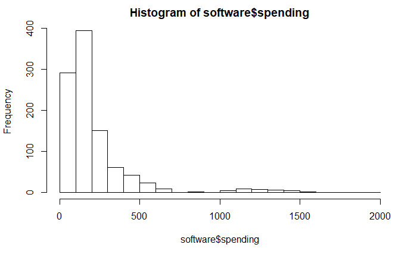

```r
hist(software$spending, breaks = seq(0,2000,100))
```

```r
mean(software$spending)
```

```
[1] 205.0906
```

1.2 Avg $ and variance of $ spent by males and females respectively

```r
mean(software$spending[software$gender==1]) #males
```

```
[1] 200.562
```

```r
sd(software$spending[software$gender==1])^2
```

```
[1] 47857.48
```

```r
var(software$spending[software$gender==1])
```

```
[1] 47857.48
```

```r
mean(software$spending[software$gender==0]) #females
```

```
[1] 209.8801
```

```r
var(software$spending[software$gender==0])
```

```
[1] 49729.48
```

1.3 t-test

```r
avgspendM <- software$spending[software$gender==1]
avgspendF <- software$spending[software$gender==0]
t.test(avgspendM,avgspendF)
```

```
    Welch Two Sample t-test

data:  avgspendM and avgspendF
t = -0.66654, df = 992.38, p-value = 0.5052
alternative hypothesis: true difference in means is not equal to 0
95 percent confidence interval:
 -36.75122  18.11511
sample estimates:
mean of x mean of y
 200.5620  209.8801
```

1.4 LM model

```r
summary(lm14)
```

```
Call:
lm(formula = spending ~ freq + last_update + first_update + web_order +
    address_res + address_us, data = softtrain)

Residuals:
    Min      1Q  Median      3Q     Max
-443.20  -95.96  -23.65   62.80 1108.17

Coefficients:
               Estimate Std. Error t value Pr(>|t|)
(Intercept)   40.997969  31.227509   1.313   0.1900
freq          92.094476   7.088768  12.992  < 2e-16 ***
last_update   -0.026558   0.013614  -1.951   0.0518 .
first_update   0.001927   0.014470   0.133   0.8942
web_order      1.793347  17.366756   0.103   0.9178
address_res  -92.940894  20.969572  -4.432 1.23e-05 ***
address_us    42.262696  23.176827   1.823   0.0690 .
---
Signif. codes:  0 ‘***’ 0.001 ‘**’ 0.01 ‘*’ 0.05 ‘.’ 0.1 ‘ ’ 1

Residual standard error: 167.5 on 372 degrees of freedom
Multiple R-squared:  0.5041,    Adjusted R-squared:  0.4961
F-statistic: 63.03 on 6 and 372 DF,  p-value: < 2.2e-16
```

1.5 ans qn using model A) cust move from non-res addr to resi addr (0 to 1) B) cust numb of trans in a year decreases by 1 unit

on avg, which of the two, will the company be worse off in terms of revenue (spending)

> A, cos lose more $$

1.6 build smaller model only sig var but leave intercept inside compare adj R, which you prefer

```r
lm16 <- lm(data=softtrain,spending~freq+address_res)
summary(lm16)
```

```
Call:
lm(formula = spending ~ freq + address_res, data = softtrain)

Residuals:
    Min      1Q  Median      3Q     Max
-449.46  -85.00  -22.48   66.90 1136.25

Coefficients:
            Estimate Std. Error t value Pr(>|t|)
(Intercept)   15.075     14.441   1.044    0.297
freq          98.679      5.219  18.909  < 2e-16 ***
address_res  -91.012     21.149  -4.303 2.15e-05 ***
---
Signif. codes:  0 ‘***’ 0.001 ‘**’ 0.01 ‘*’ 0.05 ‘.’ 0.1 ‘ ’ 1

Residual standard error: 169.2 on 376 degrees of freedom
Multiple R-squared:  0.4891,    Adjusted R-squared:  0.4864
F-statistic:   180 on 2 and 376 DF,  p-value: < 2.2e-16
```

1.7 leaps to do subset sel backwards which is drop first? comment on how this result relates to pvalue you est for FULL model

```r
summary(model17)
```

```
Subset selection object
Call: regsubsets.formula(spending ~ freq + last_update + first_update +
    web_order + address_res + address_us, softtrain, nvmax = 10,
    method = "backward")
6 Variables  (and intercept)
             Forced in Forced out
freq             FALSE      FALSE
last_update      FALSE      FALSE
first_update     FALSE      FALSE
web_order        FALSE      FALSE
address_res      FALSE      FALSE
address_us       FALSE      FALSE
1 subsets of each size up to 6
Selection Algorithm: backward
         freq last_update first_update web_order address_res address_us
1  ( 1 ) "*"  " "         " "          " "       " "         " "
2  ( 1 ) "*"  " "         " "          " "       "*"         " "
3  ( 1 ) "*"  "*"         " "          " "       "*"         " "
4  ( 1 ) "*"  "*"         " "          " "       "*"         "*"
5  ( 1 ) "*"  "*"         "*"          " "       "*"         "*"
6  ( 1 ) "*"  "*"         "*"          "*"       "*"         "*"
```

1.8 use adj r2 to pick best model which var are included

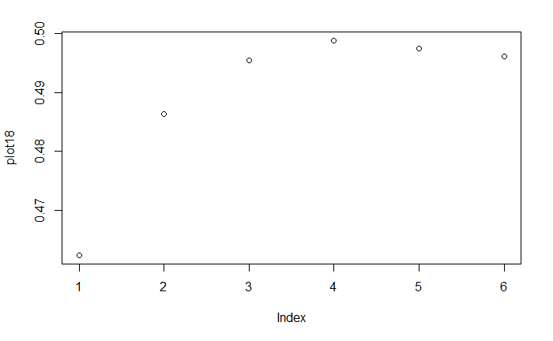

```r
plot18 <- summary(model17)$adjr2
plot(plot18)
```

```r
maxRsquare <- which.max(plot18)
maxRsquare
```

```
[1] 4
```

```r
plot18[maxRsquare]
```

```
[1] 0.4987835
```

```r
summary(model17)$which
```

```
  (Intercept) freq last_update first_update web_order address_res address_us
1        TRUE TRUE       FALSE        FALSE     FALSE       FALSE      FALSE
2        TRUE TRUE       FALSE        FALSE     FALSE        TRUE      FALSE
3        TRUE TRUE        TRUE        FALSE     FALSE        TRUE      FALSE
4        TRUE TRUE        TRUE        FALSE     FALSE        TRUE       TRUE
5        TRUE TRUE        TRUE         TRUE     FALSE        TRUE       TRUE
6        TRUE TRUE        TRUE         TRUE      TRUE        TRUE       TRUE
```

```r
summary(model17)$which[maxRsquare,]
```

```
 (Intercept)         freq  last_update first_update    web_order  address_res   address_us
        TRUE         TRUE         TRUE        FALSE        FALSE         TRUE         TRUE
```

1.9 use val set to choose btwn 3 models for all 3 what is the sse in val set

```r
ModelPredFull <- predict(lm14, newdata = softval)
ModelPredSmall <- predict(lm16, newdata = softval)
lm17 <- lm(data=softtrain,spending~freq+last_update+address_res+address_us)
ModelPredSubset <- predict(lm17, newdata = softval)
sseFULL <- sum( (ModelPredFull - softval$spending)^2 )
sseFULL
```

```
[1] 10211936
```

```r
sseSMALL <- sum( (ModelPredSmall - softval$spending)^2 )
sseSMALL
```

```
[1] 10106876
```

```r
sseSUBSET <- sum( (ModelPredSubset - softval$spending)^2 )
sseSUBSET
```

```
[1] 10203214
```

choose modelSMALL

1.10 evaluate on test set what is sse are they consistent?

```r
ModelPredFull <- predict(lm14, newdata = softtest)
ModelPredSmall <- predict(lm16, newdata = softtest)
ModelPredSubset <- predict(lm17, newdata = softtest)
sseFULL <- sum( (ModelPredFull - softtest$spending)^2 )
sseFULL
```

```
[1] 6768830
```

```r
sseSMALL <- sum( (ModelPredSmall - softtest$spending)^2 )
sseSMALL
```

```
[1] 6580861
```

```r
sseSUBSET <- sum( (ModelPredSubset - softtest$spending)^2 )
sseSUBSET
```

```
[1] 6762468
```

Pick small still.

Question 2

2.1 Which var has most numb of missing entries

```r
summary(breast)
```

```
   physician         age            shape           margin         density         severity
 Min.   :1.00   Min.   :18.00   Min.   :1.000   Min.   :1.000   Min.   :1.000   Min.   :0.0000
 1st Qu.:4.00   1st Qu.:45.00   1st Qu.:2.000   1st Qu.:1.000   1st Qu.:3.000   1st Qu.:0.0000
 Median :4.00   Median :57.00   Median :3.000   Median :3.000   Median :3.000   Median :0.0000
 Mean   :4.29   Mean   :55.49   Mean   :2.722   Mean   :2.796   Mean   :2.911   Mean   :0.4631
 3rd Qu.:5.00   3rd Qu.:66.00   3rd Qu.:4.000   3rd Qu.:4.000   3rd Qu.:3.000   3rd Qu.:1.0000
 Max.   :5.00   Max.   :96.00   Max.   :4.000   Max.   :5.000   Max.   :4.000   Max.   :1.0000
 NA's   :2      NA's   :5       NA's   :31      NA's   :48      NA's   :76
```

Density most missing @ 76

2.2 got balance? (check severity levels)

```r
table(breast$severity)
```

```
  0   1
516 445
```

```r
516/(516+445)
```

```
[1] 0.5369407
```

```r
445/(516+445)
```

```
[1] 0.4630593
```

Yes

2.3 Drop all NA entries using na.omit split into test and training 60% of data into training set seed to 1000

write the est eqn that predicts sev using age shape margin and dens and instercept

```r
glm23 <- glm(data=breasttrain,severity~age+shape+margin+density,family=binomial)
summary(glm23)
```

```
Call:
glm(formula = severity ~ age + shape + margin + density, family = binomial,
    data = breasttrain)

Deviance Residuals:
    Min       1Q   Median       3Q      Max
-2.4600  -0.5837  -0.1806   0.6420   2.3788

Coefficients:
            Estimate Std. Error z value Pr(>|z|)
(Intercept) -5.68102    1.04757  -5.423 5.86e-08 ***
age          0.05989    0.01002   5.979 2.24e-09 ***
shape        0.68018    0.12956   5.250 1.52e-07 ***
margin       0.42321    0.10367   4.082 4.46e-05 ***
density     -0.30246    0.30632  -0.987    0.323
---
Signif. codes:  0 ‘***’ 0.001 ‘**’ 0.01 ‘*’ 0.05 ‘.’ 0.1 ‘ ’ 1

(Dispersion parameter for binomial family taken to be 1)

    Null deviance: 689.98  on 497  degrees of freedom
Residual deviance: 429.13  on 493  degrees of freedom
AIC: 439.13

Number of Fisher Scoring iterations: 5
```

2.4 whats the odd ratio of age exp(0.05989)

2.5 what is LL of model on test set ?????????? what is acc of model thres 0.5

```r
-0.5*glm23$deviance
```

```
[1] -214.5668
```

2.6 use only stat sig pred var include intercept and rebuild what is LL on test set and acc?

```r
glm26 <- glm(data=breasttrain,severity~age+shape+margin,family=binomial)
summary(glm26)
```

```
Call:
glm(formula = severity ~ age + shape + margin, family = binomial,
    data = breasttrain)

Deviance Residuals:
    Min       1Q   Median       3Q      Max
-2.4626  -0.5945  -0.1870   0.6490   2.4333

Coefficients:
            Estimate Std. Error z value Pr(>|z|)
(Intercept) -6.49715    0.65655  -9.896  < 2e-16 ***
age          0.05950    0.01002   5.940 2.85e-09 ***
shape        0.67491    0.12952   5.211 1.88e-07 ***
margin       0.41573    0.10339   4.021 5.80e-05 ***
---
Signif. codes:  0 ‘***’ 0.001 ‘**’ 0.01 ‘*’ 0.05 ‘.’ 0.1 ‘ ’ 1

(Dispersion parameter for binomial family taken to be 1)

    Null deviance: 689.98  on 497  degrees of freedom
Residual deviance: 430.10  on 494  degrees of freedom
AIC: 438.1

Number of Fisher Scoring iterations: 5
```

```r
-0.5*glm26$deviance
```

```
[1] -215.0506
```

```r
BreastModelPredict2 <- predict(glm26, newdata = breasttest,type="response")
table(as.integer(BreastModelPredict2 >= 0.5),breasttest$severity)
```

```
      0   1
  0 126  20
  1  45 141
```

```r
(126+141)/(125+141+20+45)
```

```
[1] 0.8066465
```

2.7 calc partial area under ROC far FP rates which is 0.7 or larger (use model in 2.6)

```r
performance(ROCR_Predict, measure = "auc", fpr.stop=0.7)
```

```
An object of class "performance"
Slot "x.name":
[1] "None"

Slot "y.name":
[1] "Area under the ROC curve"

Slot "alpha.name":
[1] "none"

Slot "x.values":
list()

Slot "y.values":
[[1]]
[1] 0.5642113


Slot "alpha.values":
list()
```

2.8 probit?? what is LL on test set and acc?

```r
(126+140)/(125+140+21+45)
```

```
[1] 0.8036254
```

2.9 which is better? Logistic

2.10

```r
794-403
```

```
[1] 391
```

3.1

```r
cumprod(4,6,8)
```

```
Error in cumprod(4, 6, 8) :
  3 arguments passed to 'cumprod' which requires 1
```

```r
0.4*0.4 + 0.4
```

```
[1] 0.56
```

karthik_natarajan@sutd.edu.sg